**Instructor copy.** Executed notebook with all results shown, including the "after your attempt" cells. Projector/offline fallback; learners should use the notebook itself.

# f6 · Fitting a model parameter: identifiability, residuals, calibration vs validation

**Learning question:** you have a handful of observations and one adjustable number Ω in a model. How do you define the mismatch, find the best Ω, check the result on points you did not use, and recognise data that cannot determine Ω at all?

Used in: Lesson 9 (worksheet A1–A4, B1–B4); Task 02 when no download is possible. The data are invented on purpose: they were made without noise from the same equation that is fitted, so the method can be tested against the value used to make them (named in the Limits, after your attempt). Labels such as (W4), (D1), (Lesson 5) or Clinic D point to the printed one-day primers (Day 1 and Day 2 worksheets) and the detailed lessons of the classroom course in the repository. Working alone on the website, you only need the step numbers.

**Why fitting matters in CALPHAD.** The parameters in a database (such as the interaction Ω of f3–f5) are not calculated from first principles; they are chosen so that the model reproduces measurements. This notebook shows that step with the smallest possible example: one parameter, one kind of data, one temperature. The route through the notebook:

1. the data and what exactly they measure;
2. residuals and the objective: how to put "mismatch" into one number;
3. the best Ω, by a formula and by a numerical solver;
4. a test on points that were not used for the fit;
5. what goes wrong when the observable is not the one the model predicts;
6. data that cannot determine a parameter at all.

```python
# Setup: run this cell first. Locally it finds the course folder; in Colab it
# downloads the tested course release and the locked package versions.
# In Colab, the first run then restarts the session on purpose and Colab reports
# a crash: that is expected. Run this cell again, then the rest of the notebook.
RELEASE = "main"
import os, pathlib, subprocess, sys, time
ROOT = next((p for p in (pathlib.Path.cwd(), *pathlib.Path.cwd().parents)
             if (p / "pyproject.toml").is_file() and (p / "course").is_dir()), None)
if ROOT is None and "google.colab" in sys.modules:
    ROOT = pathlib.Path("/content/CalphadIntro")
    if not ROOT.is_dir():
        clone = ["git", "clone", "-q", "--depth", "1", "--branch", RELEASE,
                 "https://github.com/ukerzel/CalphadIntro.git", str(ROOT)]
        git = dict(os.environ, GIT_TERMINAL_PROMPT="0")
        if subprocess.run(clone, env=git, capture_output=True).returncode:
            raise SystemExit(f"Could not download course release {RELEASE}: check the internet "
                             "connection and run this cell again.")
    if not (ROOT / ".colab-ready").exists():
        if subprocess.run([sys.executable, "-m", "pip", "install", "-q", "-r",
                           str(ROOT / "notebooks" / "requirements-colab.txt")]).returncode:
            raise SystemExit("Installing the course packages failed; run this cell again.")
        (ROOT / ".colab-ready").touch()
        # Colab has already loaded its own numpy; a fresh session is needed to use the installed versions.
        print("Installed the course's package versions. Colab now restarts this session and"
              " reports a crash; that is expected. When it has reconnected, run this cell again"
              " (it will not install twice), then the rest of the notebook.", flush=True)
        time.sleep(3)
        os.kill(os.getpid(), 9)
if ROOT is None:
    raise SystemExit("Open this notebook from the course folder (poetry run jupyter lab) or in Colab.")
os.chdir(ROOT)
sys.path.insert(0, str(ROOT))
from notebooks.helpers import check, confirm, database, show_versions
show_versions(RELEASE)
```

```
Course release main · Python 3.12.14
  numpy       2.5.3
  scipy       1.18.1
  matplotlib  3.11.2
  xarray      2026.7.0
  pycalphad   0.11.2
```

```
True
```

## 1. What was observed, and what is fitted

The invented A–B model of f3–f5, phase ALPHA, at T = 1000 K and p = 100000 Pa. The observable is the **homogeneous ALPHA mixing enthalpy** per mole of all atoms at a given B fraction x: the enthalpy of one ALPHA solution at that composition minus the same phase's pure A and pure B enthalpies,

$$h_{\rm mix}(x)=h_{\rm ALPHA}(x)-[(1-x)\,1000+x\,13000]=\Omega\,x(1-x)\quad\mathrm{J/mol}.$$

"Homogeneous" means one composition, whether or not that state is stable. It is not what an equilibrium calculation returns (section 5).

Where the numbers 1000 and 13000 come from: in the database, pure A in ALPHA has $G=1000-10T$ and pure B has $G=13000-10T$ (J/mol). For a Gibbs energy of the form $a+bT$ the enthalpy $H=G-T\,dG/dT$ is the constant $a$ (the $bT$ term is $-TS$ with entropy $S=-b$), so the pure enthalpies are 1000 and 13000 J/mol. The ideal mixing term $RT[x\ln x+(1-x)\ln(1-x)]$ is pure entropy and contributes no enthalpy. What is left after subtracting the weighted pure enthalpies is only the interaction term $\Omega\,x(1-x)$.

Everything else in the model stays fixed (temperature, pressure, pure-element functions, ideal entropy). The only fitted number is the interaction **Ω**, allowed in 0 … 24000 J/mol.

| Quantity | Value | Unit |
| --- | --- | --- |
| temperature T | 1000 | K |
| pressure p | 100000 | Pa |
| observable | homogeneous ALPHA $h_{\rm mix}$ | J/mol of atoms |
| composition x | B atom fraction | — |
| parameter Ω | 0 … 24000 | J/mol |

The data file has two groups. The **training** points are used to choose Ω. The **held-out** points at x = 0.2, 0.4, 0.6, 0.8 are kept closed until Ω is fixed; then they test the prediction (section 4).

The data are stored in a JSON file, a common text format for structured data. `json.loads(...)` turns its text into nested Python dictionaries and lists, so `data["training"]["x_B"]` is the list of training compositions. `np.array(..., dtype=float)` turns each list into a numpy array of decimal numbers, so that arithmetic works on all points at once. The held-out enthalpies are deliberately **not** read yet.

```python
import json
from pathlib import Path

import numpy as np

data = json.loads(Path("course/foundations/binary_fit_data.json").read_text())   # nested dicts and lists
x_train = np.array(data["training"]["x_B"], dtype=float)      # B atom fraction
h_train = np.array(data["training"]["H_mix"], dtype=float)    # J/mol of atoms
x_held = np.array(data["held_out"]["x_B"], dtype=float)       # values stay closed for now
OMEGA_BOUNDS = (0.0, 24000.0)                                 # J/mol
# A name in capitals marks a constant: it is set once and not changed later.

print(f"T = {data['T_K']} K, p = {data['P_Pa']} Pa, basis: {data['amount_basis']}")
print("training:   x      h_mix (J/mol)")
for x, h in zip(x_train, h_train):        # walk through the pairs (x, h) together
    print(f"          {x:.1f}   {h:8.0f}")   # :8.0f = 8 characters wide, 0 decimals
print("held-out compositions (values not used yet):", x_held)
```

```
T = 1000 K, p = 100000 Pa, basis: mole of all atoms
training:   x      h_mix (J/mol)
          0.1       1800
          0.3       4200
          0.5       5000
          0.7       4200
          0.9       1800
held-out compositions (values not used yet): [0.2 0.4 0.6 0.8]
```

Look at the printed table: the values are symmetric about x = 0.5 and largest there, as $x(1-x)$ is. All five are positive, so mixing A and B in ALPHA costs enthalpy (Ω > 0).

## 2. Residuals and the objective (A1, A2)

A **forward model** predicts the observable at a given x for a trial Ω: $\hat h(x;\Omega)=\Omega\,a(x)$ with $a(x)=x(1-x)$ (dimensionless). The **residual** is prediction minus observation, in J/mol:

$$r_i=\Omega\,a_i-h_i .$$

A positive residual means the model predicts too much. The **objective** is the unweighted sum of squared residuals over the training points,

$$J(\Omega)=\sum_i r_i^2,\qquad [J]=(\mathrm{J/mol})^2 .$$

(J the objective, not J the joule; the units tell them apart.)

Notation: the hat in $\hat h$ marks a model prediction, and the index $i$ numbers the training points (i = 1 … 5), so $a_i=a(x_i)$ and $h_i$ is the observed value at $x_i$. The factor $a(x)$ is called the **sensitivity**: it says how much the prediction at x changes when Ω changes by 1 J/mol. It is largest at x = 0.5, where it is 0.25.

The cell defines these four quantities as small Python functions. `def name(...):` starts a function, and `return` gives back its result. Because x can be a whole numpy array, each function works on one point or on all points at once. In `objective`, `r @ r` is the dot product of the residual array with itself, $\sum_i r_i\,r_i$, which is exactly the sum of squares.

Worked trial Ω = 18000 J/mol:

```python
def a_sens(x):
    return x * (1 - x)                       # dimensionless sensitivity to Ω

def predict(omega, x):
    return omega * a_sens(x)                 # J/mol of atoms

def residuals(omega, x, h):
    return predict(omega, x) - h             # prediction − observation, J/mol

def objective(omega, x, h):
    r = residuals(omega, x, h)
    return float(r @ r)                      # (J/mol)²

trial = 18000.0   # J/mol, a trial value, not yet the best one
print("  x    prediction  observation  residual  squared residual")
for x, h in zip(x_train, h_train):
    r = residuals(trial, x, h)   # one point at a time, for the table
    print(f" {x:.1f}  {predict(trial, x):9.0f}  {h:10.0f}  {r:9.0f}  {r * r:12.0f}")
print(f"J(18000) = {objective(trial, x_train, h_train):.0f} (J/mol)²")
```

```
  x    prediction  observation  residual  squared residual
 0.1       1620        1800       -180         32400
 0.3       3780        4200       -420        176400
 0.5       4500        5000       -500        250000
 0.7       3780        4200       -420        176400
 0.9       1620        1800       -180         32400
J(18000) = 667600 (J/mol)²
```

All five residuals are negative: Ω = 18000 J/mol predicts too little at every point, so the best Ω is larger. The biggest squared residual sits at x = 0.5, where the sensitivity is largest.

Why not minimise the plain sum of residuals? Two residuals of +500 and −500 add to zero although both points are badly predicted. Squaring stops errors of opposite sign from cancelling.

### Your turn (A2)

Try Ω = 16000 J/mol by hand or with the functions above. Give the residual at x = 0.5 and the objective. Then the objective at Ω = 22000. Do the bounds 0 … 24000 alone tell you which Ω is right (True or False)?

A3, to think about: an equilibrium calculation varies phase amounts and compositions at a **fixed** model. What varies here, and what stays fixed? Would moving each observation's x until its energy drops be a valid fit?

To use the functions, type for example `residuals(16000.0, 0.5, 5000.0)` or `objective(16000.0, x_train, h_train)` in a new cell or in the cell below. Then replace each `None` by your value (`True`/`False` without quotes for the last one) and run the cell; `check` tells you whether each value matches.

```python
residual_16000_at_05 = None   # J/mol
objective_16000 = None        # (J/mol)²
objective_22000 = None        # (J/mol)²
bounds_decide_omega = None    # True or False
check(residual_16000_at_05, "f6_a2_residual_05")
check(objective_16000, "f6_a2_objective")
check(objective_22000, "f6_a2_j_22000")
check(bounds_decide_omega, "f6_a2_bounds_enough")
```

```
f6_a2_residual_05: not attempted yet. Replace None with your value and run the cell again.
f6_a2_objective: not attempted yet. Replace None with your value and run the cell again.
f6_a2_j_22000: not attempted yet. Replace None with your value and run the cell again.
f6_a2_bounds_enough: not attempted yet. Replace None with your value and run the cell again.
```

## 3. Solve the one-parameter fit (A4)

J is a parabola in Ω: $J=\sum_i(\Omega a_i-h_i)^2$. Setting $dJ/d\Omega=0$ gives

$$\Omega_*=\frac{\sum_i a_i h_i}{\sum_i a_i^2}.$$

Step by step: expanding the square gives $J=\Omega^2\sum_i a_i^2-2\Omega\sum_i a_i h_i+\sum_i h_i^2$, a parabola in Ω that opens upwards because $\sum_i a_i^2>0$. Its slope is $dJ/d\Omega=2\Omega\sum_i a_i^2-2\sum_i a_ih_i$; the minimum is where the slope is zero, which gives the formula above. A model that is linear in its parameter, as here, always leads to such a closed formula ("linear least squares").

The denominator is positive as long as at least one training point has $0<x<1$, so the minimum is unique. If $\Omega_*$ fell outside the bounds, the bounds would decide the answer instead, and that would be worth a closer look.

### Your turn (A4)

Given $\sum a_i^2=0.1669$ and $\sum a_i h_i=3338$ J/mol, what is $\Omega_*$ (J/mol)? Is a bound active (True or False)?

A bound is **active** when the best value lies on it (here at 0 or at 24000 J/mol), so that the bound, not the data, decides the result.

```python
omega_star = None         # J/mol
bound_active = None       # True or False
check(omega_star, "f6_a4_omega")
check(bound_active, "f6_a4_bound_active")
```

```
f6_a4_omega: not attempted yet. Replace None with your value and run the cell again.
f6_a4_bound_active: not attempted yet. Replace None with your value and run the cell again.
```

## After your attempt: the formula, the course fit and the objective curve

The course module `binary_fit` solves the same problem numerically (`scipy.optimize.least_squares` with the bounds) by two routes: the plain formula, and pycalphad's `calculate` on `binary_family.tdb` (f5). Both use the same observable, residual, training data and bounds. The tool route takes about 1 s.

`scipy.optimize.least_squares` is a general solver: you give it a function that returns the residual array for a trial parameter, a starting value and the bounds; it changes the parameter step by step until the sum of squares stops decreasing. It does not need the closed formula, so it also works for models where no formula exists. Its `status` number says why it stopped: a positive value (1–4) means one of its convergence tests was met, 0 means it ran out of steps. A solver that converged has found the minimum of J; whether the model is good is a separate question that only the residuals can answer.

What the cell does:

1. `confirm` checks your A2 values and the A4 formula.
2. `fits[route] = fit_interaction(...)` fits Ω by both routes, using **only** the training points. `fits` is a dictionary with one entry per route.
3. The plot shows J over the whole allowed range (solid curve), your three trial values (triangles) and the minimum (open circle). The dotted lines are the bounds.

```
✓ J(16000) reproduces the lesson value.
✓ J(18000) reproduces the lesson value.
✓ J(20000) reproduces the lesson value.
✓ J(22000) reproduces the lesson value.
✓ Residual at x = 0.5 for Ω = 16000 reproduces the lesson value.
Σa² = 0.1669, Σa·h = 3338.0 J/mol, Ω* = 20000.000000 J/mol
✓ Σa² reproduces the lesson value.
✓ Σa·h reproduces the lesson value.
✓ Ω* from the formula reproduces the lesson value.
plain route: Ω = 20000.000000 J/mol, J = 0.000000 (J/mol)², solver status 1
✓ Ω from the plain route reproduces the lesson value.
```

```
tool  route: Ω = 20000.000000 J/mol, J = 0.000000 (J/mol)², solver status 1
✓ Ω from the tool route reproduces the lesson value.
```

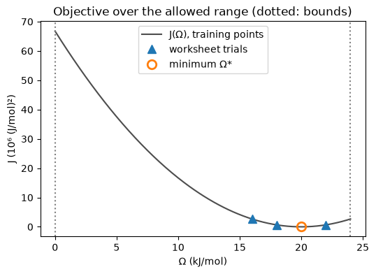

```
 Ω (J/mol)   J ((J/mol)²)
    12000       10681600
    16000        2670400
    18000         667600
    20000              0
    22000         667600
    24000        2670400
```

```python
#@title After your attempt: run to check the fit and plot J(Ω)
import matplotlib.pyplot as plt
from course.foundations.binary_fit import fit_interaction, predict_hmix

# Worksheet values of J at four trial Ω (J/mol), and the A2 residual.
for omega, expected in ((16000.0, 2670400.0), (18000.0, 667600.0), (20000.0, 0.0), (22000.0, 667600.0)):
    confirm(objective(omega, x_train, h_train), expected, f"J({omega:.0f})", tol=1e-6)
confirm(residuals(16000.0, 0.5, 5000.0), -1000.0, "Residual at x = 0.5 for Ω = 16000", tol=1e-9)

# The closed formula Ω* = Σa·h / Σa² (section 3).
a = a_sens(x_train)                                     # sensitivities of the five training points
denominator, numerator = float(a @ a), float(a @ h_train)   # Σa² (dimensionless), Σa·h (J/mol)
omega_formula = numerator / denominator                 # J/mol
print(f"Σa² = {denominator:.4f}, Σa·h = {numerator:.1f} J/mol, Ω* = {omega_formula:.6f} J/mol")
confirm(denominator, 0.1669, "Σa²", tol=1e-12)
confirm(numerator, 3338.0, "Σa·h", tol=1e-9)
confirm(omega_formula, 20000.0, "Ω* from the formula", tol=1e-5)

# The numerical fit, by the plain route and by the pycalphad ("tool") route.
fits = {}
for route in ("plain", "tool"):
    fits[route] = fit_interaction(x_train, h_train, route)   # training data only
    print(f"{route:5s} route: Ω = {fits[route]['omega']:.6f} J/mol, J = {fits[route]['sse']:.6f} (J/mol)², "
          f"solver status {fits[route]['solver_status']}")
    confirm(fits[route]["omega"], 20000.0, f"Ω from the {route} route", tol=1e-5)

# J(Ω) over the allowed range: 241 values from 0 to 24000 J/mol (steps of 100).
grid = np.linspace(*OMEGA_BOUNDS, 241)   # *OMEGA_BOUNDS unpacks the tuple into (0.0, 24000.0)
fig, ax = plt.subplots(figsize=(6, 4))
ax.plot(grid / 1000, [objective(w, x_train, h_train) / 1e6 for w in grid], "-", color="0.3", label="J(Ω), training points")   # kJ/mol on x, 10⁶ (J/mol)² on y
trials = [16000.0, 18000.0, 22000.0]
ax.plot([w / 1000 for w in trials], [objective(w, x_train, h_train) / 1e6 for w in trials], "^", ms=8, label="worksheet trials")
ax.plot([omega_formula / 1000], [0.0], "o", ms=9, mfc="none", mew=2, label="minimum Ω*")   # mfc="none": open marker
for edge in OMEGA_BOUNDS:
    ax.axvline(edge / 1000, ls=":", color="0.5")   # dotted vertical line at each bound
ax.set(xlabel="Ω (kJ/mol)", ylabel="J (10⁶ (J/mol)²)", title="Objective over the allowed range (dotted: bounds)")
ax.legend()
plt.show()
print(" Ω (J/mol)   J ((J/mol)²)")
for w in (12000.0, 16000.0, 18000.0, 20000.0, 22000.0, 24000.0):
    print(f" {w:8.0f}   {objective(w, x_train, h_train):12.0f}")
```

The curve is a parabola with its lowest point inside the bounds, and the two routes agree. J at the minimum is zero (up to rounding) only because the data contain no noise; with real data it stays positive.

## 4. Calibration, then validation (B2, B4)

**Calibration** chose Ω from the training points. **Validation** asks whether the calibrated model predicts points that took no part in choosing Ω. That only works if those points stay untouched: if you change Ω or the model after seeing them, they become training data and you need a new, honest test.

Here the held-out values were made with the same equation as the training values. A good match therefore checks the method and the code (recovery of a known value), not how well this equation describes a real alloy.

### Your turn (B2)

With Ω fixed at your fitted value, predict $h_{\rm mix}$ at x = 0.4 (J/mol). Then: may you keep tuning Ω on the held-out points and still call them untouched (True or False)?

### Your turn (B4, a fresh example)

A separate noiseless observation: x = 0.25, $h_{\rm mix}$ = 3750 J/mol. Infer Ω from this one equation, then predict at x = 0.4 without fitting again.

For B4, one observation and one unknown give one equation, $h_{\rm mix}=\Omega\,x(1-x)$, which you can solve for Ω directly. Use the function `predict(omega, x)` from section 2 for the predictions if you like.

```python
held_prediction_04 = None   # J/mol
retune_on_held_out = None   # True or False
fresh_omega = None          # J/mol, from x = 0.25 only
fresh_prediction_04 = None  # J/mol
check(held_prediction_04, "f6_b2_pred_04")
check(retune_on_held_out, "f6_b2_retune_ok")
check(fresh_omega, "f6_b4_omega")
check(fresh_prediction_04, "f6_b4_pred_04")
```

```
f6_b2_pred_04: not attempted yet. Replace None with your value and run the cell again.
f6_b2_retune_ok: not attempted yet. Replace None with your value and run the cell again.
f6_b4_omega: not attempted yet. Replace None with your value and run the cell again.
f6_b4_pred_04: not attempted yet. Replace None with your value and run the cell again.
```

## After your attempt: open the held-out values and plot data, model and residuals

Only now are the held-out enthalpies read from the file. The cell prints them next to the predictions of both fitted routes, then draws two panels:

- **left:** the fitted model curve, the trial Ω = 18000 J/mol (dashed), the training points (filled circles) and the held-out points (open squares);
- **right:** the residuals, prediction minus observation. A good fit has residuals scattered around zero; residuals that all have the same sign (as for Ω = 18000) show that the parameter is off. A residual plot often shows a problem more clearly than the curve plot, because it removes the large common shape of the data.

```
 x    stored h_mix   plain prediction   tool prediction   (J/mol)
 0.2        3200      3200.000000      3200.000000
 0.4        4800      4800.000000      4800.000000
 0.6        4800      4800.000000      4800.000000
 0.8        3200      3200.000000      3200.000000
✓ Largest held-out residual, plain route reproduces the lesson value.
✓ Largest held-out residual, tool route reproduces the lesson value.
✓ Prediction at x = 0.4 reproduces the lesson value.
✓ Ω from the single point x = 0.25 reproduces the lesson value.
```

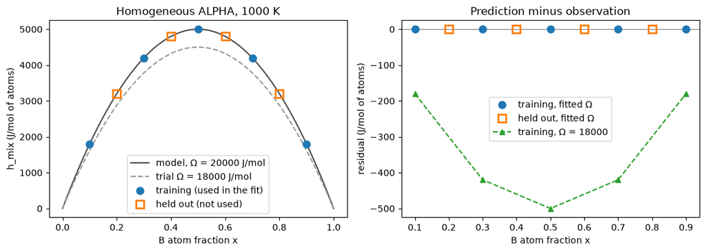

```python
#@title After your attempt: run to compare with the held-out points
h_held = np.array(data["held_out"]["H_mix"], dtype=float)   # opened only now, after the fit
omega_fit = fits["plain"]["omega"]                          # J/mol, from the training points only
print(" x    stored h_mix   plain prediction   tool prediction   (J/mol)")
# Predictions at the held-out compositions with each route's fitted Ω, J/mol.
predicted = {route: predict_hmix(fits[route]["omega"], x_held, route) for route in ("plain", "tool")}
for i, x in enumerate(x_held):
    print(f" {x:.1f}  {h_held[i]:10.0f}   {predicted['plain'][i]:14.6f}   {predicted['tool'][i]:14.6f}")
for route in ("plain", "tool"):
    # The largest absolute held-out residual must be zero (noise-free data).
    confirm(float(np.max(np.abs(predicted[route] - h_held))), 0.0, f"Largest held-out residual, {route} route", tol=1e-6)
confirm(predict(omega_fit, 0.4), 4800.0, "Prediction at x = 0.4", tol=1e-6)
confirm(3750.0 / a_sens(0.25), 20000.0, "Ω from the single point x = 0.25", tol=1e-9)

x_line = np.linspace(0, 1, 201)   # a fine composition grid for smooth curves
fig, (left, right) = plt.subplots(1, 2, figsize=(11, 4))   # two panels side by side
left.plot(x_line, predict(omega_fit, x_line), "-", color="0.3", label=f"model, Ω = {omega_fit:.0f} J/mol")
left.plot(x_line, predict(18000.0, x_line), "--", color="0.6", label="trial Ω = 18000 J/mol")
left.plot(x_train, h_train, "o", ms=8, label="training (used in the fit)")
left.plot(x_held, h_held, "s", ms=8, mfc="none", mew=2, label="held out (not used)")
left.set(xlabel="B atom fraction x", ylabel="h_mix (J/mol of atoms)", title="Homogeneous ALPHA, 1000 K")
left.legend(fontsize=10)
right.axhline(0, color="0.5", lw=0.8)   # zero line: perfect prediction
right.plot(x_train, residuals(omega_fit, x_train, h_train), "o", ms=8, label="training, fitted Ω")
right.plot(x_held, residuals(omega_fit, x_held, h_held), "s", ms=8, mfc="none", mew=2, label="held out, fitted Ω")
right.plot(x_train, residuals(18000.0, x_train, h_train), "^--", label="training, Ω = 18000")
right.set(xlabel="B atom fraction x", ylabel="residual (J/mol of atoms)", title="Prediction minus observation")
right.legend(fontsize=10)
fig.tight_layout()   # adjust spacing so labels do not overlap
plt.show()
```

## 5. The wrong observable (B1)

At 1000 K and x = 0.5 with Ω = 20000 J/mol, a tool reports the total homogeneous enthalpy $H = 12000$ J/mol. An equilibrium calculation at the same overall composition instead lets ALPHA split into two compositions (the miscibility gap of f4 and f5); after the same reference subtraction its mixture gives 2810.686236 J/mol.

The point of this section: a fit is only meaningful if the model calculates the same quantity that was measured. The model's $\Omega\,x(1-x)$ describes a homogeneous solution. If the measured number belonged to a two-phase mixture instead, comparing the two would fit Ω to the wrong thing.

### Your turn (B1)

Subtract the reference to get the homogeneous $h_{\rm mix}$ at x = 0.5 (J/mol), and give how far the equilibrium-mixture value lies below it (J/mol, positive; the nearest J/mol is enough).

The reference is the same as in section 1: $(1-x)\,1000+x\,13000$ J/mol.

```python
hmix_homogeneous_05 = None   # J/mol
equilibrium_shortfall = None # J/mol
check(hmix_homogeneous_05, "f6_b1_hmix")
check(equilibrium_shortfall, "f6_b1_error")
```

```
f6_b1_hmix: not attempted yet. Replace None with your value and run the cell again.
f6_b1_error: not attempted yet. Replace None with your value and run the cell again.
```

The next cell rebuilds the equilibrium-mixture value from the plain model. It finds the two gap compositions at 1000 K, uses the **lever rule** for their amounts, $f_{\rm right}=(z-x_{\rm left})/(x_{\rm right}-x_{\rm left})$ with z = 0.5, and averages the two homogeneous enthalpies with these amounts before subtracting the reference.

```python
#@title After your attempt: run to compute the equilibrium-mixture value
from course.foundations import binary_family as plain

left_x, right_x = plain.regular_binodal(1000.0)["compositions"]     # the two gap compositions at 1000 K
f_right = (0.5 - left_x) / (right_x - left_x)                       # lever rule
# Homogeneous enthalpy (J/mol) of ALPHA at each gap composition, Ω = 20000 J/mol.
h_left, h_right = (float(plain.regular_properties(1000.0, x, 20000.0)["HM"]) for x in (left_x, right_x))
h_mixture = (1 - f_right) * h_left + f_right * h_right - (1000 + 12000 * 0.5)   # amount-weighted, minus reference
h_homogeneous = float(plain.regular_properties(1000.0, 0.5, 20000.0)["HM"]) - (1000 + 12000 * 0.5)
print(f"gap compositions {left_x:.6f} and {right_x:.6f}, each half the amount")
print(f"homogeneous h_mix = {h_homogeneous:.6f} J/mol; equilibrium mixture = {h_mixture:.6f} J/mol")
confirm(h_homogeneous, 5000.0, "Homogeneous h_mix at x = 0.5", tol=1e-6)
confirm(h_mixture, 2810.686236, "Equilibrium-mixture h_mix at x = 0.5", tol=1e-6)
confirm(h_homogeneous - h_mixture, 2189.313764, "Shortfall of the equilibrium mixture", tol=1e-6)
```

```
gap compositions 0.169144 and 0.830856, each half the amount
homogeneous h_mix = 5000.000000 J/mol; equilibrium mixture = 2810.686236 J/mol
✓ Homogeneous h_mix at x = 0.5 reproduces the lesson value.
✓ Equilibrium-mixture h_mix at x = 0.5 reproduces the lesson value.
✓ Shortfall of the equilibrium mixture reproduces the lesson value.
```

Why the mixture value is lower: each of the two gap compositions lies far from x = 0.5, where $x(1-x)$ is small, so each has a small mixing enthalpy. Their average is therefore well below the homogeneous value at x = 0.5. If you fitted Ω to the mixture value with the homogeneous formula, you would get an Ω that is too small.

Restricting the phase list to ALPHA does not prevent the split. Do not change the observation, refit Ω or move the temperature to hide the gap: the fit would converge and still answer the wrong question. Decide what was measured first, then optimise.

## 6. Data that cannot determine a parameter (B3)

A parameter is **identifiable** from given data if different values of it give different predictions for those data.

Two cases to test:

- data only at pure A or pure B (x = 0 and x = 1), with $\hat h=\Omega\,x(1-x)$;
- an interaction that depends on temperature, $g_{\rm excess}=(A+BT)\,x(1-x)$, A in J/mol and B in J/(mol K), observed only through the enthalpy $h=g-T\,\partial g/\partial T$.

In the second case **A and B are two model coefficients**, not the elements A and B. The relation $h=g-T\,\partial g/\partial T$ follows from $g=h-Ts$ and $s=-\partial g/\partial T$ (the entropy is minus the temperature slope of g). The derivative $\partial g/\partial T$ is taken at fixed composition x.

### Your turn (B3)

What does the model predict at x = 1 for Ω = 24000 (J/mol)? Is Ω identifiable from pure-end data only? Can enthalpy data, even at many temperatures, determine B (True or False for both)?

```python
pure_end_prediction = None     # J/mol
omega_identifiable_pure = None # True or False
B_identifiable_from_h = None   # True or False
check(pure_end_prediction, "f6_b3_pure_pred")
check(omega_identifiable_pure, "f6_b3_identifiable")
check(B_identifiable_from_h, "f6_b3_B_identifiable")
```

```
f6_b3_pure_pred: not attempted yet. Replace None with your value and run the cell again.
f6_b3_identifiable: not attempted yet. Replace None with your value and run the cell again.
f6_b3_B_identifiable: not attempted yet. Replace None with your value and run the cell again.
```

The next cell tests both cases numerically. For the pure ends it evaluates J for three very different Ω and then asks the course fit to fit those data; the course fit refuses on purpose and raises an error. `try: ... except ValueError as error:` catches that error and prints its message instead of stopping the notebook.

For the temperature-dependent interaction it computes $\partial g/\partial T$ numerically with a **central difference**, $[g(T+\Delta T)-g(T-\Delta T)]/(2\Delta T)$ with $\Delta T=0.5$ K, and then the enthalpy for three values of B and two temperatures.

```python
#@title After your attempt: run to see both cases numerically
print("Pure ends: a = x(1 − x) = 0 at x = 0 and x = 1, so every Ω predicts zero mixing enthalpy there.\n"
      "Temperature-dependent interaction: ∂g/∂T = B·x(1 − x), so h = g − T·∂g/∂T = A·x(1 − x);\n"
      "the B·T term cancels and enthalpy data carry no information about B.\n")
x_pure, h_pure = np.array([0.0, 1.0]), np.array([0.0, 0.0])   # two pure-end observations, J/mol
print(" Ω (J/mol)   J for pure-end data ((J/mol)²)")
for w in (0.0, 12000.0, 24000.0):
    print(f" {w:8.0f}   {objective(w, x_pure, h_pure):.1f}")
    confirm(objective(w, x_pure, h_pure), 0.0, f"J({w:.0f}) on pure-end data", tol=1e-12)
try:
    fit_interaction(x_pure, h_pure, "plain")
except ValueError as error:   # the course fit rejects data with zero sensitivity to Ω
    print("The course fit refuses these data:", error)

def g_excess(A, B, T, x):
    return (A + B * T) * x * (1 - x)              # J/mol

def h_excess(A, B, T, x, dT=0.5):   # g is linear in T, so a central difference is exact
    dgdT = (g_excess(A, B, T + dT, x) - g_excess(A, B, T - dT, x)) / (2 * dT)   # ∂g/∂T, J/(mol K)
    return g_excess(A, B, T, x) - T * dgdT        # J/mol

print("\n B (J/(mol K))   T (K)   h_excess at x = 0.3 (J/mol), A = 20000")
values = []
for B in (-5.0, 0.0, 5.0):          # three very different B, J/(mol K)
    for T in (800.0, 1200.0):       # two temperatures, K
        values.append(h_excess(20000.0, B, T, 0.3))
        print(f" {B:6.1f}          {T:6.0f}   {values[-1]:.6f}")   # values[-1] is the last entry added
confirm(max(values) - min(values), 0.0, "Spread of h_excess over B and T", tol=1e-6)
confirm(values[0], 20000.0 * 0.3 * 0.7, "h_excess = A·x(1−x)", tol=1e-6)
```

```
Pure ends: a = x(1 − x) = 0 at x = 0 and x = 1, so every Ω predicts zero mixing enthalpy there.
Temperature-dependent interaction: ∂g/∂T = B·x(1 − x), so h = g − T·∂g/∂T = A·x(1 − x);
the B·T term cancels and enthalpy data carry no information about B.

 Ω (J/mol)   J for pure-end data ((J/mol)²)
        0   0.0
✓ J(0) on pure-end data reproduces the lesson value.
    12000   0.0
✓ J(12000) on pure-end data reproduces the lesson value.
    24000   0.0
✓ J(24000) on pure-end data reproduces the lesson value.
The course fit refuses these data: endmember-only data have zero sensitivity to omega

 B (J/(mol K))   T (K)   h_excess at x = 0.3 (J/mol), A = 20000
   -5.0             800   4200.000000
   -5.0            1200   4200.000000
    0.0             800   4200.000000
    0.0            1200   4200.000000
    5.0             800   4200.000000
    5.0            1200   4200.000000
✓ Spread of h_excess over B and T reproduces the lesson value.
✓ h_excess = A·x(1−x) reproduces the lesson value.
```

Every Ω fits pure-end data equally well, and every B gives the same enthalpies. An optimiser would still return *some* number; that number would be an accident of its starting point, not a result. Information that depends on entropy (for example data at several temperatures that involve G, not only H) is needed to determine B.

In the J(Ω) picture of section 3: for pure-end data the curve is completely flat, so there is no lowest point to find. A flat (or nearly flat) objective is the sign of a parameter the data cannot determine.

Worked answers: instructor guide (A1–B4); reading: Lesson 9.

## 7. Limits

The data are invented and noise-free, generated with the same equation that is fitted. Recovering Ω = 20000 J/mol shows that the method and code work; it says nothing about any real alloy, and there is no uncertainty to report. Real measurements scatter, often have different uncertainties, and the model may not have the right form; then the residuals do not vanish and a held-out check can fail. One parameter at one temperature is the simplest case: a real assessment adjusts many parameters against several kinds of data. Next: Task 02 · two Cu–Ni interaction values from nine Ni activities.